# Introdução à Ciência de Dados

Prof. Washington Santos da Silva

IFMG - Campus Formiga

16 de abril de 2025

## Diário de Bordo

**O que vimos até hoje?**

- Aula 1 ✅
  - Introdução e Contextualização ✅
  - O que é Ciência de Dados? ✅
  - Papéis Profissionais na Área de Dados ✅
  - Áreas de Aplicações ✅
  - Habilidades Interpessoais e Analíticas ✅
  - Apresentação da Disciplina ✅
- Aula 2 ✅
  - Metodologia CRISP-DM ✅
  - Tipos de Análise ✅
    - Descritiva ✅
    - Diagnóstica ✅
    - Preditiva ✅
    - Prescritiva ✅
  - Configurações: Git/GitHub ✅
- Aula 3 ✅
  - Introdução ao RStudio ✅
    - Criação do **seu** Projeto RStudio da Disciplina ✅
- Aula 4 ✅
  - Introdução ao Git e GitHub ✅
    - Criação do **seu** repositório do projeto RStudio da disciplina no GitHub ✅
- Aula 5 ✅
  - Breve Revisão do IDE RStudio ✅
  - Introdução ao Sistema de Publicação Quarto ✅
  - Sessão Prática Guiada com Relatório 1 ✅
    - Execução dos comandos git essenciais ✅
- Aula 6 ✅
  - Parte I ✅
    - O Relatório Junglivet e a Metodologia CRISP-DM ✅
    - Primeiro contato com a linguagem R por meio dos códigos do relatório ✅
  - Parte II ✅
    - Para alunos com projetos estruturados ✅
    - Atividade prática ✅
    - Para alunos com dificuldades técnicas ✅
    - Atendimento individualizado para estruturação de projetos ✅

## Objetivos da Aula 6

**O que **esperávamos** alcançar?**

1. **Todos os alunos** com:
   - Projeto RStudio estruturado corretamente
   - Repositório Git/GitHub funcionando
   - Relatório Junglivet renderizado com sucesso
2. **Preparação para**:
   - Iniciar o aprendizado formal da linguagem R
   - Importação e manipulação básica de dados

## Nesta Aula

**Tópicos**

- Introdução ao sistema Quarto (continuação):
  - Gerar relatório no formato pdf
  - Gerar relatório no formato docx
- Introdução à Linguagem R (continuação):
  - Conceitos: Variáveis e observações
  - Estrutura tabular organizada de dados
  - Tipos e classes de dados principais em R
  - Estruturas de dados: vetores e data frames

**Diretrizes para Aulas Mais Produtivas**

🔊 **Mantenha conversas em volume baixo**

⌨️ **Código com método:**

95% dos erros são evitáveis com:

- Atenção na digitação
- Respeitar a sequência lógica de etapas
- Revisão antes de pedir ajuda

🤝 **Inteligência colaborativa:**

- Compartilhe conhecimento
- Resolva questões técnicas simples com colegas próximos
- Reserve ao professor as dúvidas conceituais complexas

💪 **Capacidade de Resolver Problemas**

Cada erro resolvido é uma evolução da sua habilidade analítica

# Introdução ao sistema Quarto (cont.)

## Relatórios em Diferentes Formatos

**Relatórios em pdf e docx**

Para finalizar a introdução ao sistema de publicação Quarto vamos:

1. Gerar um relatório no formato `pdf` para o relatório contendo o estudo de caso sobre a destilaria Junglivert (`01-relatorio-html.qmd`).
2. Gerar um relatório no formato `docx` para o mesmo relatório da Junglivert.

## Relatório no formato pdf

**Instruções**

- Abra o Rstudio e o seu projeto RStudio da disciplina.
- Abra o Windows Explorer
- Copie o arquivo `01-relatorio-html.qmd` para subpasta **02-relatorio** da pasta relatorios.
- Renomeie esse arquivo como `02-relatorio-pdf.qmd`
- No RStudio, abra o arquivo `02-relatorio-pdf.qmd`
- Apague todo o cabeçalho yaml, copie o cabeçalho do próximo slide e cole no local do cabeçalho anterior.
- Renderize o arquivo `02-relatorio-pdf.qmd` clicando em **Render**.

## Cabeçalho para Relatório pdf

```yaml
---
title: "Caso Junglivet Whisky Company"
subtitle: "Introdução à CRISP-DM, RStudio, Sistema Quarto e Linguagem R"
lang: pt-BR
author: "Seu Nome"
date: 2025-04-16
date-format: long
format:
  typst:
    columns: 1
    toc: true
    papersize: a4
    fontsize: 12pt
    number-sections: true
execute:
  echo: true
  warning: false
  message: false
---
```

## Relatório no formato docx

**Instruções**

- Abra o Windows Explorer
- Copie o arquivo `01-relatorio-html.qmd` para subpasta **03-relatorio** da pasta relatorios.
- Renomeie esse arquivo como `03-relatorio-docx.qmd`
- No RStudio, abra o arquivo `03-relatorio-docx.qmd`
- Apague todo o cabeçalho yaml, copie o cabeçalho do próximo slide e cole no local do cabeçalho anterior.
- Renderize o arquivo `03-relatorio-docx.qmd` clicando em **Render**.

## Cabeçalho para Relatório docx

```yaml
---
title: "Caso Junglivet Whisky Company"
subtitle: "Introdução à CRISP-DM, RStudio, Sistema Quarto e Linguagem R"
lang: pt-BR
author: "Seu Nome"
date: 2025-04-16
format:
  docx:
    number-sections: true
execute:
  message: false
  warning: false
  echo: true
---
```

## Sistema Quarto: Um Diferencial

**Vantagens Estratégicas para Administradores**

- **Reprodutibilidade como valor profissional**
  - Análises que podem ser verificadas, auditadas e atualizadas automaticamente
  - Documentação completa do processo decisório baseado em dados
- **Comunicação eficiente em múltiplos formatos**
  - Mesmo código gera relatórios em diferentes formatos (html, pdf, docx) e para públicos diferentes.
  - Transição fluida entre análise técnica e apresentação executiva

## Sistema Quarto: Um Diferencial

**Vantagens Estratégicas para Administradores**

- **Diferencial competitivo no mercado**
  - Domínio de ferramentas modernas de análise de dados
  - Capacidade de integrar áreas técnicas e de negócios
- **Economia de tempo e redução de erros**
  - Fim do ciclo “copiar e colar” entre análises e relatórios
  - Atualizações instantâneas quando os dados mudam
- **Credibilidade técnica em ambientes corporativos**
  - Demonstração tangível de rigor analítico
  - Comunicação profissional com base em evidências

## Atualizando os Repositórios

**Instruções**

1. No terminal do RStudio, verifique quais arquivos/pastas foram modificados ou criados com:

```bash
git status
```

2. Você pode adicionar todos os arquivos de uma vez com:

```bash
git add .
```

3. Execute git status novamente para confirmar que todos os arquivos foram adicionados (aparecerão em verde sob “*Changes to be committed*”):

```bash
git status
```

4. Se tudo estiver em verde, faça um commit com uma mensagem descritiva:

```bash
git commit -m "atualizacoes aula 7"
```

5. Se algum arquivo ou pasta ainda aparecer em vermelho após o segundo git status, adicione as pastas/arquivos um por um:

```bash
git add relatorios/02-relatorio/02-relatorio-pdf.qmd
git add relatorios/03-relatorio/03-relatorio-docx.qmd
```

6. Execute git status novamente e faça o commit quando todos os arquivos estiverem em verde:

```bash
git commit -m "atualizacoes aula 7"
```

7. Envie o repositório local atualizado para o GitHub:

```bash
git push origin main
```

# Introdução à Linguagem R (cont.)

## Conceito Estatístico: Variáveis

**Definição**

Em Estatística, uma **variável** é uma característica que pode variar em valor entre os indivíduos de uma amostra ou população.

- Qualquer característica que podemos medir para os elementos de uma população (ou amostra) é chamada de *variável*.
- O termo reflete o fato de que os valores da característica variam entre os elementos de uma população.

## Conceito Estatístico: Observações

**Definição**

Em Estatística, uma **observação** representa uma unidade amostral individual dentro de um conjunto de dados.

- Cada observação corresponde a um elemento específico da população ou amostra (por exemplo, uma pessoa, uma empresa, um país)
- Cada observação contém valores para diversas variáveis, formando um registro completo de características para aquela unidade específica
- O conjunto de todas as observações constitui o conjunto de dados que analisamos

## Relação entre Variáveis e Observações

**Descrição**

**Estrutura dos dados**: Organizamos os dados em formato tabular onde:

- Cada **linha** representa **uma** observação individual
- Cada **coluna** representa **uma** variável específica
- Cada **célula** contém **um** valor de **uma** variável para **uma** observação específica
- Esta estrutura é necessária para permitir a análise de dados.
- **Intuição**: Se as variáveis são “**o que**” medimos, as observações são “**sobre quem**” ou “**sobre o que**” estamos medindo.

## Dados em Formato Tabular

```markdown
┌─────────────────────────────────────────┐
│                                         │
│          Variáveis (Colunas)            │
│    ┌──────┬──────┬──────┬──────┐        │
│    │ Var1 │ Var2 │ Var3 │ Var4 │        │
│    ├──────┼──────┼──────┼──────┤        │
│    │  •   │  •   │  •   │  •   │  Obs1  │
│    ├──────┼──────┼──────┼──────┤        │
│ O  │  •   │  •   │  •   │  •   │  Obs2  │
│ b  ├──────┼──────┼──────┼──────┤        │
│ s  │  •   │  •   │  •   │  •   │  Obs3  │
│ e  ├──────┼──────┼──────┼──────┤        │
│ r  │  •   │  •   │  •   │  •   │  Obs4  │
│ v  ├──────┼──────┼──────┼──────┤        │
│ a  │  •   │  •   │  •   │  •   │  Obs5  │
│ ç  ├──────┼──────┼──────┼──────┤        │
│ õ  │  •   │  •   │  •   │  •   │  Obs6  │
│ e  ├──────┼──────┼──────┼──────┤        │
│ s  │  •   │  •   │  •   │  •   │  Obs7  │
│    ├──────┼──────┼──────┼──────┤        │
│    │  •   │  •   │  •   │  •   │  Obs8  │
│    └──────┴──────┴──────┴──────┘        │
│                                         │
└─────────────────────────────────────────┘
```

## Exemplo: Dados Desorganizados

```markdown
| Departamento | Vendas 2023 T1 | Vendas 2023 T2 | Vendas 2023 T3 | Vendas 2023 T4 | Despesas 2023 T1 | Despesas 2023 T2 | Despesas 2023 T3 | Despesas 2023 T4 | Funcionários 2023 T1 | Funcionários 2023 T2 | Funcionários 2023 T3 | Funcionários 2023 T4 |
|--------------|----------------|----------------|----------------|----------------|------------------|------------------|------------------|------------------|----------------------|----------------------|----------------------|----------------------|
| Marketing    | 120.000        | 150.000        | 180.000        | 210.000        | 80.000           | 90.000           | 95.000           | 110.000          | 12                   | 14                   | 14                   | 15                   |
| Vendas       | 350.000        | 420.000        | 380.000        | 520.000        | 150.000          | 160.000          | 155.000          | 175.000          | 25                   | 28                   | 30                   | 32                   |
| Operações    | 90.000         | 95.000         | 100.000        | 110.000        | 70.000           | 75.000           | 80.000           | 85.000           | 18                   | 18                   | 20                   | 22                   |
```

Por que estes dados estão desorganizados?

- **As colunas contém mais de uma variável**: As informações sobre ano e trimestre estão incorporadas nos nomes das colunas ao invés de serem colunas (variável) separadas.
- **Estrutura rígida e difícil de expandir**: Adicionar um novo ano ou um novo tipo de métrica exigiria criar várias colunas novas.
- **Análise temporal comprometida**: Dificulta a análise de tendências ao longo do tempo, por exemplo, comparar o mesmo trimestre em anos diferentes.
- **Cálculos complexos**: Calcular métricas derivadas como lucro (vendas - despesas) se torna uma tarefa complicada.
- **Visualização limitada**: Criar gráficos de série temporal ou comparar métricas entre departamentos requer manipulação prévia dos dados.

## Exemplo: Dados Organizados

```markdown
| Departamento | Ano  | Trimestre | Métrica      | Valor    |
|--------------|------|-----------|--------------|----------|
| Marketing    | 2023 | T1        | Vendas       | 120.000  |
| Marketing    | 2023 | T2        | Vendas       | 150.000  |
| Marketing    | 2023 | T3        | Vendas       | 180.000  |
| Marketing    | 2023 | T4        | Vendas       | 210.000  |
| Marketing    | 2023 | T1        | Despesas     | 80.000   |
| Marketing    | 2023 | T2        | Despesas     | 90.000   |
| Marketing    | 2023 | T3        | Despesas     | 95.000   |
| Marketing    | 2023 | T4        | Despesas     | 110.000  |
| Marketing    | 2023 | T1        | Funcionários | 12       |
| Marketing    | 2023 | T2        | Funcionários | 14       |
| Marketing    | 2023 | T3        | Funcionários | 14       |
| Marketing    | 2023 | T4        | Funcionários | 15       |
| Vendas       | 2023 | T1        | Vendas       | 350.000  |
| Vendas       | 2023 | T2        | Vendas       | 420.000  |
| ...          | ...  | ...       | ...          | ...      |
```

## Conceito Estatístico: Tipos de Variáveis

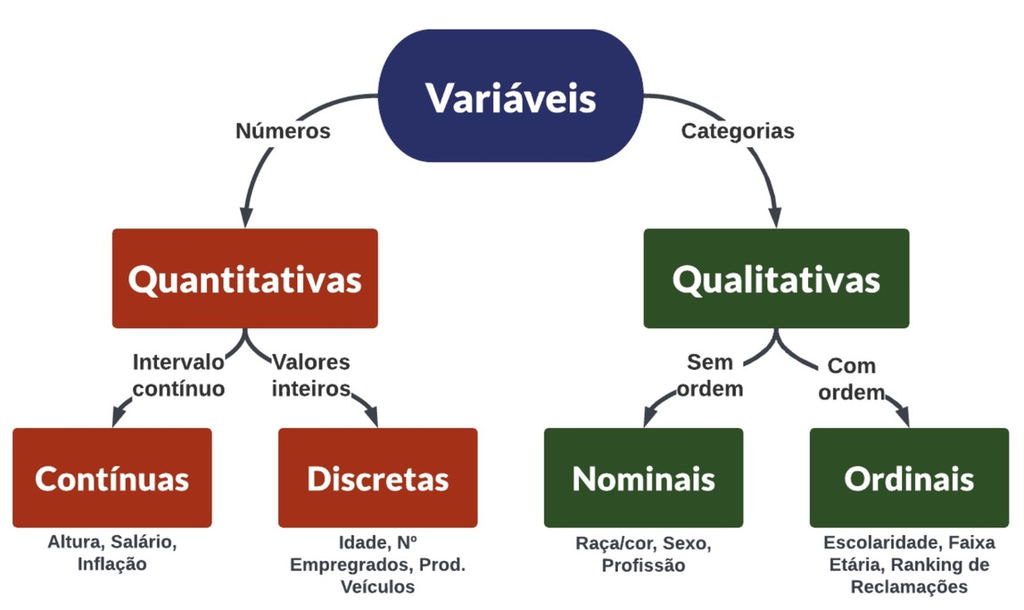

## Variáveis Quantitativas/Numéricas

**Definição**

- Uma variável é chamada de **quantitativa** quando a escala de medição possui valores numéricos que representam diferentes magnitudes da variável.
- Variáveis quantitativas são frequentemente chamadas de **numéricas**.
- Uma variável quantitativa é **discreta** se puder assumir um conjunto de valores distintos, como os inteiros não negativos $(0, 1, 2, 3, \ldots)$.
- Uma variável quantitativa é **contínua** se puder assumir um continuum infinito de possíveis valores de números reais, pelo menos teoricamete.
- Na prática, arredondamos variáveis contínuas ao medi-las, de modo que a medida real é discreta. Ainda assim, estas variáveis são tratadas como variáveis contínuas.
- **Os métodos de análise estatística dependem da escala de medição (tipo) de uma variável de interesse**.

## Variáveis Qualitativas/Categóricas

**Definição**

Uma variável é chamada de **categórica** quando a escala de medição é um conjunto de categorias.

- Variáveis categóricas cque possuem apenas duas categorias, como empregado (sim ou não), são também chamadas de **binárias**.
- Variáveis categóricas são frequentemente chamadas de **qualitativas**.
- Variáveis categóricas possuem dois tipos de escalas de medição: **nominal** e **ordinal**.
- Escala **Nominal**: Quando as categorias nõa possuem uma hierarquia. Exemplos: cor, sexo, racá, etc.
- Escala **Ordinal**: Quando as categorias possuem uma hierarquia natural. Exemplos: Nível de Escolaridade (Fundamental, Médio e Superior). Score de Crédito (risco pequeno, risco moderado, alto risco), etc.
- **Os métodos de análise estatística dependem da escala de medição (tipo) de uma variável de interesse**.

## Tipos e Classes de Dados

**A Importância de Conhecer Tipos e Classes de Dados**

- Se os métodos de análise estatística dependem da escala de medição (tipo) de uma variável de interesse, compreender os tipos e classes de dados da linguagem R (ou de qualquer outra) é fundamental.
- Cada tipo de análise ou de gráfico exige que as variáveis sejam de um tipo ou classe específicos e estejam organizadas em uma estrutura de dados específica.
- Na prática da ciência ou análise de dados, estima-se que analistas e cientistas dedicam entre 60% a 80% do tempo de um projeto à importação, limpeza e preparação dos dados antes de iniciar as análises.

## Tipos/Classes Principais

| Tipo | Classe | Descrição |
| --- | --- | --- |
| `double` | `numeric` | armazena valores reais (números com casas decimais) |
| `integer` | `numeric` | armazena valores inteiros (números sem casas decimais) |
| `character` | `character` | armazena valores de texto (caracteres) |
| `logical` | `logical` | armazena valores lógicos (`TRUE`/`FALSE`) |
| `NA` |  | `Not Available`: representa valores faltantes |
| `NaN` |  | `Not a Number`: exemplo: 0/0 |
| `Inf` |  | `Infinity`: exemplo: 1/0 |

**Dicas**

- O **tipo atômico** se refere a como R armazena o objeto internamente.
- A **classe** se refere a como R trata um objeto em operações e funções.

## Tipos Atômicos Principais

- Após importarmos um arquivo de dados e verificarmos como R entendeu cada coluna/variável importada, precisamos converter os tipos definidos para classes adequadas para análises posteriores.

| Tipo | Converter para | Função para Conversão |
| --- | --- | --- |
| `double` | `numeric` | `as.numeric()` |
| `integer` | `numeric` (ou `integer`) | `as.numeric` (ou `as.integer`) |
| `character` | `factor` | `as.factor` |

## Classe `factor`

**Descrição**

- A classe `factor` da linguagem R é apropriada para representar variáveis categóricas nominais ou ordinais.

```r
# Vetor de texto com dados brutos
estado_civil <- c(
  "Casado", "Solteiro", "Divorciado", "Solteiro",
  "Casado", "Viúvo", "Solteiro", "Divorciado"
)

# Convertendo para fator (variável categórica nominal)
estado_civil_fator <- factor(estado_civil)

# Vizualizando o objetoa
estado_civil_fator
```

```
[1] Casado     Solteiro   Divorciado Solteiro   Casado     Viúvo      Solteiro
[8] Divorciado
Levels: Casado Divorciado Solteiro Viúvo
```

```r
# verificando a classe
class(estado_civil_fator)
```

```
[1] "factor"
```

## Classe `factor`

```r
# Vetor de texto com dados brutos
escolaridade <- c(
  "Médio", "Fundamental", "Superior", "Superior",
  "Médio", "Pós-graduação", "Fundamental", "Médio"
)

# Convertendo para fator ordenado com níveis explícitos
escolaridade_fator <- factor(escolaridade,
  levels = c("Fundamental", "Médio", "Superior", "Pós-graduação"),
  ordered = TRUE # indica que é um fator ordenado
)

# Visualizando o fator e sua estrutura
escolaridade_fator
```

```
[1] Médio         Fundamental   Superior      Superior      Médio
[6] Pós-graduação Fundamental   Médio
Levels: Fundamental < Médio < Superior < Pós-graduação
```

```r
# verificando a classe
class(escolaridade_fator)
```

```
[1] "ordered" "factor"
```

## Exemplo: Relatório JungLivert

**Verificando a estrutura dos dados**

- Após importar os dados, analisamos o tipo de cada variável (coluna) importada.

```r
# Importa o arquivo de dados

## Define o caminho relativo do arquivo no projeto RStudio
caminho <- here::here("dados/brutos/productionlog_sample.csv")

## Importa o arquivo com a funçào read_csv
dados_destilaria <- readr::read_csv(caminho)

# Verificar a estrutura dos dados
dplyr::glimpse(dados_destilaria)
```

```
Rows: 21
Columns: 8
$ DAY          <dbl> 1, 1, 2, 2, 3, 3, 4, 4, 5, 5, NA, 6, 6, 7, 7, 8, 8, 9, 9,…
$ MONTH        <dbl> 4, 4, 4, 4, 4, 4, 4, 4, 4, 4, NA, 4, 4, 4, 4, 4, 4, 4, 4,…
$ MANUFACTURER <chr> "Leonard", "Carlson", "Leonard", "Carlson", "Leonard", "C…
$ PRODUCT      <chr> "Junglivet", "Junglivet Premium", "Junglivet", "Junglivet…
$ SHIFT        <chr> "Morning", "Evening", "Morning", "Evening", "Morning", "E…
$ COLOR        <dbl> 0.27, 0.27, 0.28, 0.32, 0.32, 0.28, 0.29, 0.29, 0.33, 0.2…
$ MALTING      <chr> "Inhouse", "Burns Best Ltd.", "Inhouse", "Inhouse", "Matr…
$ TASTING      <dbl> 895, 879, 938, 900, 917, 900, 934, 951, 852, 850, NA, 991…
```

## Exemplo: Relatório JungLivert

```r
dados_destilaria_limpos <- dados_destilaria %>%
  select(-MONTH) %>%
  rename(
    dia = DAY,
    mestre_responsavel = MANUFACTURER,
    tipo_produto = PRODUCT,
    turno = SHIFT,
    cor = COLOR,
    fornecedor_malte = MALTING,
    indicador_qualidade = TASTING,
  ) %>%
  # Em seguidda, convertemos cada variável para classes adequadas
  mutate(
    dia = as.numeric(dia),
    mestre_responsavel = as.factor(mestre_responsavel),
    tipo_produto = as.factor(tipo_produto),
    turno = as.factor(turno),
    cor = as.numeric(cor),
    fornecedor_malte = as.factor(fornecedor_malte),
    indicador_qualidade = as.numeric(indicador_qualidade)
  ) %>%
  drop_na()
```

## Estruturas de Dados Principais

**Vetor**

- **Estrutura fundamental** em R: todos os tipos básicos são armazenados como vetores
- **Definição**: Coleção de elementos do **mesmo tipo** de dados
- **Criação** com a função `c()` (concatenate/combine):

## Vetores - exemplos

```r
# cria um vetor numérico manualmente
idades <- c(22, 25, 19, 30, 27)
idades
```

```
[1] 22 25 19 30 27
```

```r
# cria um vetor de caracteres
nomes <- c("Ana", "Bruno", "Carla", "Daniel", "Eduarda")
nomes
```

```
[1] "Ana"     "Bruno"   "Carla"   "Daniel"  "Eduarda"
```

```r
# cria um vetor lógico
aprovados <- c(TRUE, FALSE, TRUE, TRUE, FALSE)
aprovados
```

```
[1]  TRUE FALSE  TRUE  TRUE FALSE
```

## Estruturas de Dados Principais

**Data Frames e Tibbles**

- **Data frame**: Estrutura tabular (similar a uma planilha Excel)
  - Coleção de vetores **de mesmo comprimento** mas que podem ser de **tipos diferentes**
  - Cada coluna = um vetor = uma variável
  - Cada linha = uma observação
- **Tibble**: Versão moderna de data frame do pacote `tibble` (parte do `tidyverse`)
  - Mais consistente e previsível que as data frames
  - Inclui o tipo de cada coluna ao imprimir
  - Não converte strings em fatores automaticamente

## Data Frames e Tibbles

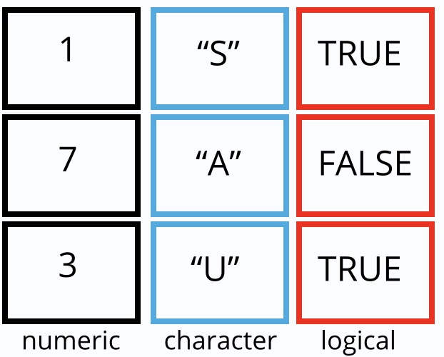

Representação Visual

## Exemplo de data frame/tibble

```r
# cria vetores manualmente
idades <- c(22, 25, 19, 30, 27)
nomes <- c("Ana", "Bruno", "Carla", "Daniel", "Eduarda")
aprovados <- c(TRUE, FALSE, TRUE, TRUE, FALSE)

# a funcao data.frame cria uma data frame usando os vetores
dados <- data.frame(idades, nomes, aprovados)

# exibe a data frame criada
dados
```

```
  idades   nomes aprovados
1     22     Ana      TRUE
2     25   Bruno     FALSE
3     19   Carla      TRUE
4     30  Daniel      TRUE
5     27 Eduarda     FALSE
```

## Exemplo de data frame/tibble

```r
# head exibe as 6 primeiras linhas de um objeto
head(dados_destilaria_limpos)
```

```
# A tibble: 6 × 7
    dia mestre_responsavel tipo_produto      turno     cor fornecedor_malte
  <dbl> <fct>              <fct>             <fct>   <dbl> <fct>
1     1 Leonard            Junglivet         Morning  0.27 Inhouse
2     1 Carlson            Junglivet Premium Evening  0.27 Burns Best Ltd.
3     2 Leonard            Junglivet         Morning  0.28 Inhouse
4     2 Carlson            Junglivet         Evening  0.32 Inhouse
5     3 Leonard            Junglivet         Morning  0.32 Matro Ltd.
6     3 Carlson            Junglivet         Evening  0.28 Inhouse
# ℹ 1 more variable: indicador_qualidade <dbl>
```

## Acessando uma Coluna/Variável

```r
# acesse com $
dados_destilaria_limpos$indicador_qualidade
```

```
 [1] 895 879 938 900 917 900 934 951 852 850 991 950 863 936 996 978 989 999 831
[20] 822
```

## Acessando uma Coluna/Variável

```r
# acesse com $
dados_destilaria_limpos$fornecedor_malte
```

```
 [1] Inhouse         Burns Best Ltd. Inhouse         Inhouse
 [5] Matro Ltd.      Inhouse         Inhouse         Matro Ltd.
 [9] Matro Ltd.      Inhouse         Inhouse         Inhouse
[13] Burns Best Ltd. Burns Best Ltd. Burns Best Ltd. Matro Ltd.
[17] Inhouse         Inhouse         Burns Best Ltd. Matro Ltd.
Levels: Burns Best Ltd. Inhouse Matro Ltd.
```

## data frame e tibble

```r
# exibe a estrutura dos dados
class(dados_destilaria_limpos)
```

```
[1] "tbl_df"     "tbl"        "data.frame"
```

**Data Frames e Tibbles**

- Ao importar dados, todo objeto lido por R como uma data frame, também será uma tibble.

## Recursos Adicionais

- [Introdução ao RStudio](https://washingtonsilva.github.io/tutorials/rstudio/)
- [Introdução ao Sistema Quarto](https://washingtonsilva.github.io/tutorials/quarto/)
- [Markdown](https://washingtonsilva.github.io/tutorials/markdown/)
- [Introdução à Linguagem R](https://washingtonsilva.github.io/tutorials/R/)
- [Controle de Versão com Git e GitHub](https://washingtonsilva.github.io/tutorials/git/)